# Bayesian Model Averaging, Default Priors & Prediction Accuracy

#### IMDB Rating

The scatterplot (Figure 32) suggests a strong positive correlation between IMDB rating and audience score.

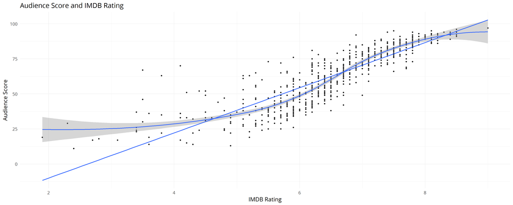

Figure 32: Audience Score and IMDB Rating

A Pearson product-moment correlation coefficient was computed to assess the relationship between imdb rating and audience scores. There was a positive correlation between the two variables, r = 0.862 n = 643 p = 0. As supported by the scatterplot, a strong positive correlation between imdb rating and audience score was observed

#### Runtime

The scatterplot (Figure 33) suggests a weak positive correlation between runtime and audience score.

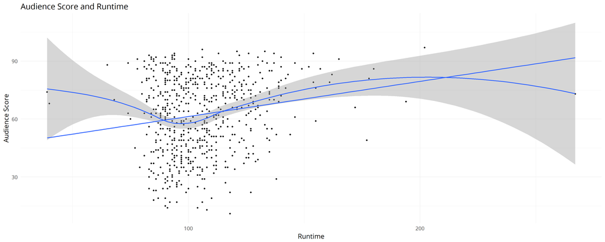

Figure 33: Audience Score and Runtime

A Pearson product-moment correlation coefficient was computed to assess the relationship between runtime and audience scores. There was a positive correlation between the two variables, r = 0.176 n = 643 p = 0. As supported by the scatterplot, a weak positive correlation between runtime and audience score was extant

#### Year of Theatrical Release

The scatterplot (Figure 34) suggests the lack of a correlation between the year of theatrical release and audience score.

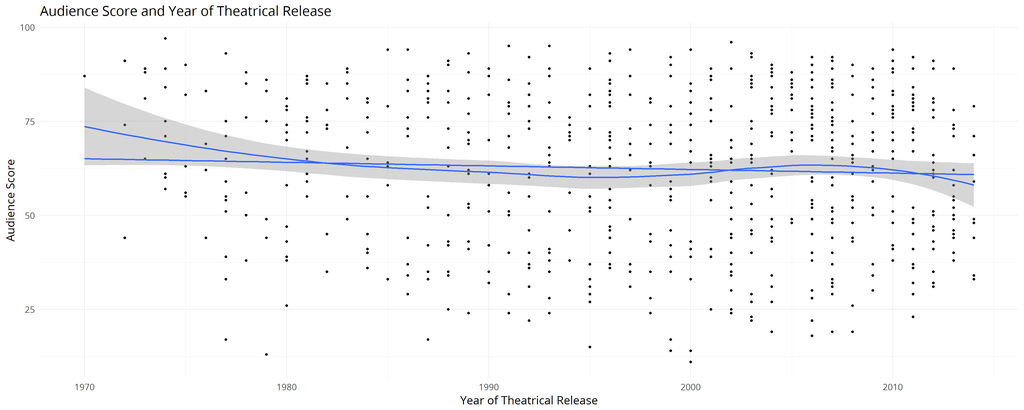

Figure 34: Audience Score and Year of Theatrical Release

# References

John James jjames@datasciencesalon.org

04 March, 2018